# Testing the effect of fuel price of fishing effort using GFW

```r
library(tidyverse)
library(modelr)
library(broom)
library(DBI)
library(bigrquery)
library(trelliscopejs)
library(rvest)
library(lubridate)
library(googleCloudStorageR)
library(ggsci)
library(ggseas)
library(pryr)
library(grid)
library(gtable)
library(cowplot)
BQ_connection <-  dbConnect(dbi_driver(), dataset = "", project = "ucsb-gfw")
```

This analysis looks at the question: How does changes in fuel price affect the observed fishing effort in GFW?. This analysis is motivated by the fact that global fuel prices have decreased by ~70% from 2012 to 2016.

## 1. Get fuel price

We will use daily global prices of Marine Diesel Oil ($/MT) obtained from the [BUNKER INDEX](http://www.bunkerindex.com/prices/bixfree.php?priceindex_id=4) website and average them across month and weeks for our analysis.

```r
daily_fuel_prices <- read_csv("saved_files/daily_fuel_prices.csv")
daily_fuel_prices <- daily_fuel_prices %>%
  mutate(date = lubridate::ymd(date),
         fuel_price = as.numeric(price)) %>%
  group_by(date) %>%
  summarise(fuel_price = mean(fuel_price, na.rm = T)) %>%
  arrange(date)
monthly_fuel_price <- daily_fuel_prices %>%
  mutate(date = round_date(date, "month")) %>%
  group_by(date) %>%
  summarize(fuel_price = mean(fuel_price, na.rm = T)) %>%
  ungroup() %>%
  mutate(lagged_fuel_price = lag(fuel_price, 1L))
weekly_fuel_price <- daily_fuel_prices %>%
  group_by(date = cut(date, "week")) %>%
  summarize(fuel_price = mean(fuel_price, na.rm = T)) %>%
  ungroup() %>%
  select(date, fuel_price) %>%
  mutate(date = date(date),
         lagged_fuel_price = lag(fuel_price, 1L))
```

## 2. Selecting vessel sample

To obtain the adecuate sample of vessels such that we can control for increase coverage and AIS use, we need to select vessels that were active during the entire time period (2012-2016). For this, we use a cutoff rule of **minimum 10 active days in every year** where active implies at least 1 position with speed greater than 1 knot

```r
consistently_active_mmsi <- src_bigquery(project = "ucsb-gfw", dataset = "fao_v2") %>%
  tbl("all_years_clean_effort") %>%
  filter(speed > 1) %>%
  group_by(year, mmsi, country) %>%
  summarize(active_days = exact_count_distinct(date(timestamp))) %>%
  filter(active_days >= 10) %>%
  ungroup() %>%
  group_by(mmsi, country) %>%
  summarize(years = exact_count_distinct(year)) %>%
  filter(years > 4) %>%
  select(-years) %>%
  collect() %>%
  ungroup()
```

[output not shown]

```r
BQ_connection <-  dbConnect(dbi_driver(), dataset = "fuel_analysis", project = "ucsb-gfw")
if(dbExistsTable(BQ_connection, "consistently_active_mmsi")){
  dbRemoveTable(BQ_connection, "consistently_active_mmsi")
  dbWriteTable(BQ_connection, "consistently_active_mmsi", consistently_active_mmsi %>% select(-country))
} else {dbWriteTable(BQ_connection, "consistently_active_mmsi", consistently_active_mmsi %>% select(-country))}
```

```
[1] TRUE
```

In total, this represents 9982 vessels, from 77 different flag states but mainly from China.

## 3 Monthly Analysis

### 3.1 Estimating distance traveled and fuel comsumption

Then, we use these vessels and aggregate their effort (hours), distance traveled, and fuel consumption by month. We exclude effort in 2012 since this is the first year of GFW and data quality is not great.

```r
monthly_effort_by_mmsi <- src_bigquery(project = "ucsb-gfw", dataset = "fao_v2") %>%
  tbl("all_years_clean_effort") %>%
  filter(mmsi %in% consistently_active_mmsi$mmsi, year != 2012) %>%
  mutate(month = month(timestamp)) %>%
  group_by(year, month, mmsi, country) %>%
  summarize(active_hours = sum(ifelse(speed > 1, hours, 0)),
            distance_traveled = sum(ifelse(prev_gapmeters >= 0, prev_gapmeters,0)),
            hours_distance = sum(ifelse(speed > 1, distance_from_shore*hours, 0))) %>%
  filter(active_hours > 0 , distance_traveled > 0, hours_distance > 0 ) %>%
  ungroup() %>%
  collect(n = Inf)

monthly_effort_by_mmsi <- monthly_effort_by_mmsi %>%
  mutate(date = make_date(year = year, month = month)) %>%
  select(date, mmsi, country, active_hours, distance_traveled, hours_distance) %>%
  arrange(date) %>%
  left_join(monthly_fuel_price) %>%
  replace_na(list(country = "unknown"))

write_rds(monthly_effort_by_mmsi, "saved_files/monthly_effort_by_mmsi")
```

```r
monthly_effort_by_mmsi <- readRDS("saved_files/monthly_effort_by_mmsi")
monthly_effort_by_mmsi <- monthly_effort_by_mmsi %>%
  group_by(mmsi) %>%
  mutate(lagged_distance_traveled = lag(distance_traveled, order_by = mmsi),
         month = as.factor(month(date, label = TRUE)),
         country = as.factor(country)) %>%
  ungroup() %>%
  arrange(date)
```

### 3.2 Visualizing trends

#### All countries combined

```r
monthly_effort_by_mmsi %>%
  group_by(date) %>%
  summarise(active_hours = sum(active_hours)) %>%
  arrange(date) %>%
  ggplot(aes(x = date, y = active_hours))+
  geom_line() +
  geom_smooth()+
  ggtitle("monthly effort (hours) all countries combined")+
  theme_minimal()

monthly_effort_by_mmsi %>%
  group_by(date) %>%
  summarise(total_distance_traveled = sum(distance_traveled)) %>%
  arrange(date) %>%
  ggplot(aes(x = date, y = total_distance_traveled))+
  geom_line() +
  geom_smooth()+
  ggtitle("Distance traveled per month all countries all vessels")+
  theme_minimal()
```

#### By country

```r
monthly_effort_by_mmsi %>%
  group_by(date, country) %>%
  summarise(total_distance_traveled = sum(distance_traveled)) %>%
  arrange(date) %>%
  ggplot() +
  geom_path(aes(x = date, y = total_distance_traveled)) +
  theme_minimal() +
  geom_smooth(aes(x = date, y = total_distance_traveled)) +
  trelliscopejs::facet_trelliscope(~country, self_contained = TRUE)
```

### 3.3 Decomposing seasonal patterns

```r
detrending_function <- function(df, y_var, time_step){
  if (time_step == "weekly") {
  foo <- as.formula(paste(y_var,'~', "as.factor(month(date)) + as.logical(week(date) %in% c(52,53,1))"))
  lm(foo , data = df)
  }
  else if (time_step == "monthly") {
  foo <- as.formula(paste(y_var,'~', "as.factor(month(date))"))
  lm(foo , data = df)
  }
  else
  {stop("Time step in not valid")}
}

detrended_plot <- function(detrended_df){
  ggplot(detrended_df) +
    geom_path(aes(x = date, y = residuals)) +
    geom_smooth(aes(x = date, y = residuals))
}

fuel_plot <- function(df, var){
  ggplot(df) +
    geom_point(aes_string(x = "log(fuel_price)", y =  var)) +
    geom_smooth(aes_string(x = "log(fuel_price)", y = var))
}

get_fuel_coefs <- function(df, y_var, time_step){
  if (time_step == "weekly") {
    foo <- as.formula(paste(y_var, "~", "factor(lubridate::month(date)) +  as.logical(week(date) %in% c(52,53,1)) + log(fuel_price)"))
    broom::tidy(lm(foo , data = df))
  }
  else if (time_step == "monthly") {
    foo <- as.formula(paste(y_var, "~", "factor(lubridate::month(date)) + log(fuel_price)"))
    broom::tidy(lm(foo , data = df))
  }
  else{stop("Time step not valid")}
}
```

```r
nested_monthly_df <- monthly_effort_by_mmsi %>%
  filter(!is.na(country)) %>%
  group_by(date, country) %>%
  summarise(fuel_price = mean(fuel_price),
            distance_traveled = sum(distance_traveled, na.rm = T),
            active_hours = sum(active_hours, na.rm = T),
            hours_distance = sum(hours_distance, na.rm = T)) %>%
  ungroup() %>%
  group_by(country) %>%
  nest(.key = "grouped_data")
nested_monthly_df_by_mmsi <- monthly_effort_by_mmsi %>%
  filter(!is.na(country)) %>%
  group_by(country) %>%
  nest(.key = "ungrouped_data")
nested_monthly_df <- nested_monthly_df %>%
  left_join(nested_monthly_df_by_mmsi)
```

```r
detrended_monthly_distance_traveled <- nested_monthly_df %>%
  mutate(detrended_model = map(grouped_data, detrending_function, y_var = "distance_traveled", time_step = "monthly"),
         residuals = purrr::map2(grouped_data, detrended_model, add_residuals, "residuals"),
         detrended_plots = trelliscopejs::map_plot(residuals, detrended_plot),
         fuel_plots = trelliscopejs::map_plot(grouped_data, fuel_plot, var = "log(distance_traveled)"),
         fuel_coefs = purrr::map(ungrouped_data, get_fuel_coefs, y_var = "log(distance_traveled)", time_step = "monthly"))

detrended_monthly_distance_traveled %>%
  trelliscopejs::trelliscope(name = "detrended distance traveled", self_contained = TRUE)

detrended_monthly_distance_traveled %>%
  unnest(fuel_coefs) %>%
  filter(term == "log(fuel_price)", p.value < 0.05) %>%
  ggplot(aes(x = country, y = estimate, color = estimate > 0))+
  geom_point() +
  coord_flip()
```

### 3.4 Fixed Effect Regressions

###### Model 1.1: Just log-log

$$ln(\text{distance_traveled}) = \alpha_0 + \alpha_1 ln(\text{fuel_price}) + \epsilon$$

```r
monthly_distance_model_1.1 = lm(log(distance_traveled) ~ log(fuel_price), data = monthly_effort_by_mmsi)
```

###### Model 1.2: Monthly Log-Log with country and month fixed effects

$$ln(\text{distance_traveled}) = \alpha_0 + \alpha_1 ln(\text{fuel_price}) + \alpha_2 \text{country} + \alpha_3 \text{month} + \epsilon$$

```r
monthly_distance_model_1.2 = lm(log(distance_traveled) ~ country + month + log(fuel_price), data = monthly_effort_by_mmsi)
```

###### Model 1.3: Monthly log-log with country and month fixed effects and lagged fuel price

$$ln(\text{distance_traveled}) = \alpha_0 + \alpha_1 ln(\text{fuel_price}_{t-1}) + \alpha_2 \text{country} + \alpha_3 \text{month} + \epsilon$$

```r
monthly_distance_model_1.3 = lm(log(distance_traveled) ~ country + month + log(lagged_fuel_price) , data = monthly_effort_by_mmsi)
```

#### Models summary

```r
stargazer::stargazer(monthly_distance_model_1.1, monthly_distance_model_1.2, monthly_distance_model_1.3,
                     type = 'html',
                     omit  = c("country","month"),
                     ci = TRUE)
```

#### Comparing elasticity estimates with other published estimates in other sectors

```r
Hughes_elasticity_recent = -0.041
Hughes_elasticity_past = -0.335
Havnarek_elasticity = -0.09
Winebreak_elasticity = 0.005
```

```r
monthly_intercept = monthly_distance_model_1.1$coefficients[1]
monthly_GFW_elasticity = monthly_distance_model_1.1$coefficients[2]

monthly_slopes <- tibble(source = c("Global Fishing Fleet", "Global meta-analysis of gasoline demand", "U.S per capita gasoline consumption (1975-1980)", "U.S per capita gasoline consumption (2001-2006)",  "U.S Trucking sector"),
                 elasticity = c(monthly_GFW_elasticity, Havnarek_elasticity, Hughes_elasticity_past, Hughes_elasticity_recent, Winebreak_elasticity))

monthly_limits <- ggplot2::aes(ymax = -0.009, ymin = -0.034)

monthly_elasticity_bar_plot <- ggplot(monthly_slopes,
                   aes(x = forcats::fct_reorder(source, elasticity), y = elasticity, fill = source)) +
  geom_bar(stat = "identity", width = .5) +
  theme_minimal() +
  scale_x_discrete(position = "top") +
  theme(axis.text.x = element_text(angle = 22, hjust = .03),
        plot.margin = unit(c(0, 1.5, 0.2, .2), "in")) +
  xlab("") +
  guides(fill = FALSE) +
  scale_fill_npg() +
  geom_errorbar(data = monthly_slopes %>% filter(source == "Global Fishing Fleet"),  monthly_limits,  stat = "identity", width = 0.25)+
  ylab("price elasticity of fuel demand")


monthly_elasticity_bar_plot
```

### 3.5 Plotting fuel price and distance timeseries

```r
monthly_fuel_ts_plot_base_R.pryr %<a-%{

   par(mar = c(4, 4, 4, 5))
plot(monthly_fuel_price_ts,
     type = 'l',
     ylab = "Fuel price ($ per metric ton)",
     las = 1,
     col = "navyblue",
     bty = "u")
par(new = T)
plot(monthly_deseasoned_ts,
     type = 'l',
     yaxt = 'n',
     ylab = '',
     col = "grey80",
     bty = "n")
lines(monthly_distance_trend_ts,
     type = 'l',
     yaxt = 'n',
     ylab = '',
     col = "red")
axis(side = 4, las = 1)
mtext(side = 4, 'Distance traveled (million km)', line = 3.5)
legend("bottomleft",bty='n',col=c("navyblue","grey80",2),lty=1,
       legend=c("Fuel price","Distance traveled (km)","Trend"), cex = .8, xjust = 0.5)
 }

monthly_fuel_ts_plot_base_R.pryr
```

```r
monthly_price_ts_plot <- decomposed_monthly_distance_df %>%
  ggplot(aes(x = date, y = fuel_price)) +
  geom_line(color = "navyblue") +
  theme(panel.border = element_rect(fill=NA, size=0.5, color = "black",
                                    linetype="solid"),
        panel.background = element_blank(),
        panel.grid.minor = element_blank(),
        panel.grid.major = element_blank(),
        panel.grid.major.x = element_blank(),
        plot.title = element_text(hjust = -0.035 ,vjust = 2.12, colour = "navyblue", size = 10),
        plot.subtitle = element_text(hjust = -0.06 ,vjust = 2.12, colour = "navyblue", size = 10),
        axis.text.y = element_text(colour = "navyblue", size = 10),
        axis.text.x = element_text(size = 10),
        axis.line =   element_blank()) +
  #ggtitle("Fuel price",subtitle = "($ per metric ton)") +
  labs(x = NULL, y = NULL)
monthly_distance_ts_plot <- decomposed_monthly_distance_df %>%
  mutate_at(vars(original_data,trend,decomposed_distance), funs(./1000000)) %>%
  ggplot(labels = scales::comma) +
  geom_line(aes(x = date, y = decomposed_distance), color = "grey80") +
  geom_line(aes(x = date, y = trend), color = "#00A4E6") +
  theme(panel.grid.minor = element_blank(),
        panel.grid.major = element_blank(),
        panel.grid.major.x = element_blank(),
        panel.background = element_blank(),
        #axis.line.y = element_blank(),
        plot.title = element_text(hjust = .99 ,vjust=2.12, colour="#00A4E6", size = 10),
        plot.subtitle = element_text(hjust = .99 ,vjust=2.12, colour="#00A4E6", size = 10),
        axis.text.y = element_text(colour="#00A4E6", size = 10),
        axis.text.x = element_text(size = 10),
        axis.line =   element_blank())+
  ggtitle("Distance traveled",subtitle =" (million km)") +
  labs(x=NULL, y= NULL)+
  scale_x_date(limits = c(ymd("2013-01-01"),ymd("2016-12-31")))
```

```r
make_double_axis_plot <- function(p1,p2){
  # Get the plot grobs
  g1 <- ggplotGrob(p1)
  g2 <- ggplotGrob(p2)

  # Get the locations of the plot panels in g1.
  pp <- c(subset(g1$layout, name == "panel", se = t:r))

  # Overlap panel for second plot on that of the first plot

  g1 <- gtable_add_grob(g1, g2$grobs[[which(g2$layout$name == "panel")]], pp$t, pp$l, pp$b, pp$l)

  # ggplot contains many labels that are themselves complex grob;
  # usually a text grob surrounded by margins.
  # When moving the grobs from, say, the left to the right of a plot,
  # make sure the margins and the justifications are swapped around.
  # The function below does the swapping.
  # Taken from the cowplot package:
  # https://github.com/wilkelab/cowplot/blob/master/R/switch_axis.R

  hinvert_title_grob <- function(grob){
    # Swap the widths
    widths <- grob$widths
    grob$widths[1] <- widths[3]
    grob$widths[3] <- widths[1]
    grob$vp[[1]]$layout$widths[1] <- widths[3]
    grob$vp[[1]]$layout$widths[3] <- widths[1]

    # Fix the justification
    grob$children[[1]]$hjust <- 1 - grob$children[[1]]$hjust
    grob$children[[1]]$vjust <- 1 - grob$children[[1]]$vjust
    grob$children[[1]]$x <- unit(1, "npc") - grob$children[[1]]$x
    grob
    }
  # Get the y axis from g2 (axis line, tick marks, and tick mark labels)
  index <- which(g2$layout$name == "axis-l")  # Which grob
  yaxis <- g2$grobs[[index]]                  # Extract the grob

  # yaxis is a complex of grobs containing the axis line, the tick marks, and the tick mark labels.
  # The relevant grobs are contained in axis$children:
  #   axis$children[[1]] contains the axis line;
  #   axis$children[[2]] contains the tick marks and tick mark labels.

  # Second, swap tick marks and tick mark labels
  ticks <- yaxis$children[[2]]
  ticks$widths <- rev(ticks$widths)
  ticks$grobs <- rev(ticks$grobs)

  # Third, move the tick marks
  # Tick mark lengths can change.
  # A function to get the original tick mark length
  # Taken from the cowplot package:
  # https://github.com/wilkelab/cowplot/blob/master/R/switch_axis.R

  plot_theme <- function(p) {
    plyr::defaults(p$theme, theme_get())
    }

  tml <- plot_theme(p1)$axis.ticks.length   # Tick mark length

  ticks$grobs[[1]]$x <- ticks$grobs[[1]]$x - unit(1, "npc") + tml

  # Fourth, swap margins and fix justifications for the tick mark labels
  ticks$grobs[[2]] <- hinvert_title_grob(ticks$grobs[[2]])

  # Fifth, put ticks back into yaxis
  yaxis$children[[2]] <- ticks

  # Put the transformed yaxis on the right side of g1

  g1 <- gtable_add_cols(g1, g2$widths[g2$layout[index, ]$l], pp$r)
  g1 <- gtable_add_grob(g1, yaxis, pp$t, pp$r + 1, pp$b, pp$r + 1, clip = "off", name = "axis-r")

  # Labels grob
  left = textGrob(paste("     Fuel Price","($ per metric ton)", sep = "\n"), x = 0, y = 0.5, just = c("left", "top"), gp = gpar(fontsize = 10, col =  "navyblue"))
  right =  textGrob(paste("Distance Traveled", "(million km)    ", sep = "\n"), x = 1, y = 0.5, just = c("right", "top"), gp = gpar(fontsize = 10, col =  "#00A4E6"))
  labs = gTree("Labs", children = gList(left, right))

  # New row in the gtable for labels
  height = unit(3, "grobheight", left)
  g1 <- gtable_add_rows(g1, height, 2)

  # Put the label in the new row
  g1 = gtable_add_grob(g1, labs, t = 3, l = 3, r = 5)

  # Turn off clipping in the plot panel
  g1$layout[which(g1$layout$name == "panel"), ]$clip = "off"

  g1
}
```

```r
monthly_double_axis_plot <- make_double_axis_plot(monthly_price_ts_plot,monthly_distance_ts_plot)
grid.draw(monthly_double_axis_plot)
```

```r
china_plot <- readRDS("final_figures/chinese_moratoria_plot")
monthly_multi_panel_plot <- ggdraw() +
  draw_plot(china_plot, 0, .5, 1, .5) +
  draw_plot(monthly_double_axis_plot, 0, 0, .5, .5) +
  draw_plot(monthly_elasticity_bar_plot, .5, 0, .5, .5) +
  draw_plot_label(c("A", "B", "C"), c(0, 0, 0.5), c(1, 0.5, 0.5), size = 12)
save_plot("final_figures/monthly_multi_panel_plot.pdf", monthly_multi_panel_plot,
          ncol = 1, # we're saving a grid plot of 2 columns
          nrow = 3,
          base_aspect_ratio = 1:5,
          base_width = 15
          )
```

## 4 Weekly Analysis

### 4.1 Estimating distance traveled and fuel comsumption

Trying a similar approach to monthly aggregates (see below) gives a seeminlgy correct answer. However, closer inspection of the results reveals that some dates get parsed as NA (those with week number = 53) which is a problem for joining with the fuel price data

A workaround is to aggregate by day in BQ, save the output to GCS, import the huge table to R and then do the same workflow using `cut()` function to group and summarize by week. Ideally I would like to run and save the query to BQ using `bigrquery` (I know how) and then export the results to gcs using the terminal and executing: `bq extract 'fuel_analysis.daily_effort_by_mmsi' gs://scratch_juan/daily_effort_by_mmsi.csv`.So far no luck on running the terminal from R so for now I read from GCS directly as follows:

```r
googleCloudStorageR::gcs_auth()
gcs_global_bucket("scratch_juan")
download_gcs_file <- gcs_get_object("daily_effort_by_mmsi.csv",  saveToDisk = "saved_files/daily_effort_by_mmsi.csv") # this downloads the daily file from GCS

daily_effort_by_mmsi <- read_csv(file = "saved_files/daily_effort_by_mmsi.csv") %>%
  arrange(date)

weekly_effort_by_mmsi <- daily_effort_by_mmsi %>%
  group_by(date = cut(date, "week"), mmsi, country) %>%
  summarize(active_hours = sum(active_hours, na.rm = T),
            distance_traveled = sum(distance_traveled, na.rm = T),
            hours_distance = sum(hours_distance, na.rm = T)) %>%
  ungroup() %>%
  mutate(date = date(date)) %>%
  left_join(weekly_fuel_price) %>%
  filter(active_hours > 0 , distance_traveled > 0, hours_distance > 0  )

weekly_effort_by_mmsi <- weekly_effort_by_mmsi %>%
  filter(!date %in% c(date("2012-12-31"), date("2016-12-26")))

write_rds(weekly_effort_by_mmsi, "saved_files/weekly_effort_by_mmsi")
```

```r
weekly_effort_by_mmsi <- readRDS("saved_files/weekly_effort_by_mmsi")
weekly_effort_by_mmsi <- weekly_effort_by_mmsi %>%
  group_by(mmsi) %>%
  mutate(lagged_distance_traveled = lag(distance_traveled, order_by = mmsi),
         month = as.factor(month(date, label = TRUE)),
         country = as.factor(country),
         new_year = as.logical(week(date) %in% c(52))) %>%
  ungroup() %>%
  arrange(date)
```

### 4.2 Visualizaing trends

#### All countries combined

```r
weekly_effort_by_mmsi %>%
  group_by(date) %>%
  summarise(active_hours = sum(active_hours)) %>%
  arrange(date) %>%
  ggplot(aes(x = date, y = active_hours))+
  geom_line()+
  geom_smooth()+
  ggtitle("Weekly effort (hours) all countries combined")+
  theme_minimal()

weekly_effort_by_mmsi %>%
  group_by(date) %>%
  summarise(total_distance_traveled = sum(distance_traveled)) %>%
  arrange(date) %>%
  ggplot(aes(x = date, y = total_distance_traveled)) +
  geom_line()+
  geom_smooth()+
  ggtitle("Distance traveled per week all countries all vessels")+
  theme_minimal()
```

#### By country

```r
weekly_effort_by_mmsi %>%
  group_by(date, country) %>%
  summarise(total_distance_traveled = sum(distance_traveled)) %>%
  arrange(date) %>%
  ggplot() +
  geom_path(aes(x = date, y = total_distance_traveled)) +
  theme_minimal() +
  geom_smooth(aes(x = date, y = total_distance_traveled)) +
  trelliscopejs::facet_trelliscope(~country, self_contained = TRUE)
```

### 4.3 Decomposing seasonal patterns

Lets detrend these time series to account for seasonality (month fixed effects) and for holidays.

```r
nested_weekly_df <- weekly_effort_by_mmsi %>%
  filter(!is.na(country)) %>%
  group_by(date, country) %>%
  summarise(fuel_price = mean(fuel_price),
            distance_traveled = sum(distance_traveled, na.rm = T),
            active_hours = sum(active_hours, na.rm = T),
            hours_distance = sum(hours_distance, na.rm = T)) %>%
  ungroup() %>%
  group_by(country) %>%
  nest(.key = "grouped_data")
nested_weekly_df_by_mmsi <- weekly_effort_by_mmsi %>%
  filter(!is.na(country)) %>%
  group_by(country) %>%
  nest(.key = "ungrouped_data")
nested_weekly_df <- nested_weekly_df %>%
  left_join(nested_weekly_df_by_mmsi)
```

```r
detrended_weekly_distance_traveled <- nested_weekly_df %>%
  mutate(detrended_model = map(grouped_data, detrending_function, y_var = "distance_traveled", time_step = "weekly"),
         residuals = purrr::map2(grouped_data, detrended_model, add_residuals, "residuals"),
         detrended_plots = trelliscopejs::map_plot(residuals, detrended_plot),
         fuel_plots = trelliscopejs::map_plot(grouped_data, fuel_plot, var = "log(distance_traveled)"),
         fuel_coefs = purrr::map(ungrouped_data, get_fuel_coefs, y_var = "log(distance_traveled)", time_step = "weekly"))


detrended_weekly_distance_traveled %>%
  trelliscopejs::trelliscope(name = "detrended distance traveled", self_contained = TRUE)

detrended_weekly_distance_traveled %>%
  trelliscopejs::trelliscope(name = "detrended distance traveled", panel_col = "fuel_plots", self_contained = TRUE)

detrended_weekly_distance_traveled %>%
  unnest(fuel_coefs) %>%
  filter(term == "log(fuel_price)", p.value < 0.05) %>%
  ggplot(aes(x = country, y = estimate, color = estimate > 0))+
  geom_point() +
  coord_flip()
```

### 4.4 Fixed Effects regression

###### Model 2.1: Just log-log:

$$ln(\text{distance_traveled}) = \alpha_0 + \alpha_1 ln(\text{fuel_price})$$

```r
weekly_distance_model_2.1 = lm(log(distance_traveled) ~ log(fuel_price), data = weekly_effort_by_mmsi)
```

###### Model 2.2: Log-Log with country, month and new years fixed effect

$$ln(\text{distance_traveled}) = \alpha_0 + \alpha_1 ln(\text{fuel_price}) + \alpha_2 \text{country} + \alpha_3 \text{month} + \alpha_4\text{new_years} + \epsilon$$

```r
weekly_distance_model_2.2 = lm(log(distance_traveled) ~ log(fuel_price) + country + month + new_year , data = weekly_effort_by_mmsi)
```

###### Model 2.3. Log-Log with country, month and new years fixed effect with a **lagged** fuel price

```r
weekly_distance_model_2.3 = lm(log(distance_traveled) ~ country + month + new_year  + log(lagged_fuel_price) , data = weekly_effort_by_mmsi)
```

```r
weekly_distance_model_2.3 = lm(log(distance_traveled) ~ country + month + new_year  + log(lagged_fuel_price) , data = weekly_effort_by_mmsi)
```

###### Comparing elasticity estimates with other published estimates in other sectors

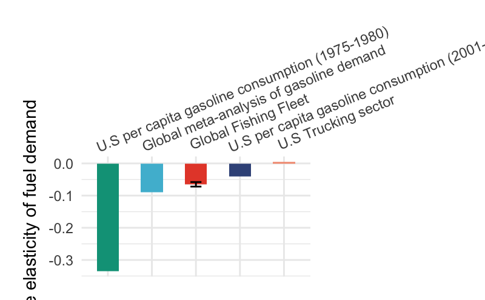

```r
weekly_intercept = weekly_distance_model_2.1$coefficients[1]
weekly_GFW_elasticity = weekly_distance_model_2.1$coefficients[2]
weekly_slopes <- tibble(source = c("Global Fishing Fleet", "Global meta-analysis of gasoline demand", "U.S per capita gasoline consumption (1975-1980)", "U.S per capita gasoline consumption (2001-2006)",  "U.S Trucking sector"),
                 elasticity = c(weekly_GFW_elasticity, Havnarek_elasticity, Hughes_elasticity_past, Hughes_elasticity_recent, Winebreak_elasticity))
weekly_limits <- ggplot2::aes(ymax = -0.058, ymin = -0.072)
weekly_elasticity_bar_plot <- ggplot(weekly_slopes,
                   aes(x = forcats::fct_reorder(source, elasticity), y = elasticity, fill = source)) +
  geom_bar(stat = "identity", width = .5) +
  theme_minimal() +
  scale_x_discrete(position = "top") +
  theme(axis.text.x = element_text(angle = 22, hjust = .03),
        plot.margin = unit(c(0, 1.5, 0.2, .2), "in")) +
  xlab("") +
  guides(fill = FALSE) +
  scale_fill_npg() +
  geom_errorbar(data = weekly_slopes %>% filter(source == "Global Fishing Fleet"),  weekly_limits,  stat = "identity", width = 0.25) +
  ylab("price elasticity of fuel demand")


weekly_elasticity_bar_plot
```

### 4.5 Plotting fuel price and distance timeseries

```r
total_distance_by_week <- weekly_effort_by_mmsi %>%
  group_by(date) %>%
  summarise(distance_traveled = sum(distance_traveled),
            fuel_price = mean(fuel_price, na.rm = T))
weekly_distance_ts <- ts(total_distance_by_week$distance_traveled, start = c(2013, 1), frequency = 52)
weekly_fuel_price_ts <- ts(total_distance_by_week$fuel_price, start = c(2013, 1), frequency = 52)
decomposed_weekly_distance_ts <- decompose(weekly_distance_ts, "additive")
decomposed_weekly_distance_df <- data_frame(original_data = as.double(decomposed_weekly_distance_ts$x),
                                     trend = as.double(decomposed_weekly_distance_ts$trend),
                                     decomposed_distance = as.double(decomposed_weekly_distance_ts$x) - as.double(decomposed_weekly_distance_ts$seasonal),
                                     fuel_price = total_distance_by_week$fuel_price,
                                     date = total_distance_by_week$date)
weekly_deseasoned_ts <- ts(as.double(decomposed_weekly_distance_ts$x) - as.double(decomposed_weekly_distance_ts$seasonal),start = c(2013, 1), frequency = 52)/1000000
weekly_distance_trend_ts <- decomposed_weekly_distance_ts$trend/1000000
weekly_fuel_price_ts <- ts(total_distance_by_week$fuel_price, start = c(2013, 1), frequency = 52)
```

```r
weekly_fuel_ts_plot_base.pryr %<a-%{

   par(mar = c(4, 4, 4, 5))
plot(weekly_fuel_price_ts,
     type = 'l',
     ylab = "Fuel price ($ per metric ton)",
     las = 1,
     col = "navyblue",
     bty = "u")
par(new = T)
plot(weekly_deseasoned_ts,
     type = 'l',
     yaxt = 'n',
     ylab = '',
     col = "grey80",
     bty = "n")
lines(weekly_distance_trend_ts,
     type = 'l',
     yaxt = 'n',
     ylab = '',
     col = "red")
axis(side = 4, las = 1)
mtext(side = 4, 'Distance traveled (million km)', line = 3.5)
legend("bottomleft",bty = 'n',col = c("navyblue","grey80",2), lty = 1,
       legend = c("Fuel price", "Distance traveled (km)", "Trend"), cex = .8, xjust = 0.5)
 }

weekly_fuel_ts_plot_base.pryr
```

```r
weekly_price_ts_plot <- decomposed_weekly_distance_df %>%
  ggplot(aes(x = date, y = fuel_price)) +
  geom_line(color = "navyblue") +
  theme(panel.border = element_rect(fill=NA, size=0.5, color = "black",
                                    linetype="solid"),
        panel.background = element_blank(),
        panel.grid.minor = element_blank(),
        panel.grid.major = element_blank(),
        panel.grid.major.x = element_blank(),
        plot.title = element_text(hjust = -0.035 ,vjust = 2.12, colour = "navyblue", size = 10),
        plot.subtitle = element_text(hjust = -0.06 ,vjust = 2.12, colour = "navyblue", size = 10),
        axis.text.y = element_text(colour = "navyblue", size = 10),
        axis.text.x = element_text(size = 10),
        axis.line =   element_blank()) +
  #ggtitle("Fuel price",subtitle = "($ per metric ton)") +
  labs(x = NULL, y = NULL) +
  scale_y_continuous(breaks  = c(300,500,750,1000), limits = c(300, 1050))
weekly_distance_ts_plot <- decomposed_weekly_distance_df %>%
  mutate_at(vars(original_data,trend,decomposed_distance), funs(./1000000)) %>%
  ggplot(labels = scales::comma) +
  geom_line(aes(x = date, y = decomposed_distance), color = "grey80") +
  geom_line(aes(x = date, y = trend), color = "#00A4E6") +
  theme(panel.grid.minor = element_blank(),
        panel.grid.major = element_blank(),
        panel.grid.major.x = element_blank(),
        panel.background = element_blank(),
        #axis.line.y = element_blank(),
        plot.title = element_text(hjust = .99 ,vjust=2.12, colour="#00A4E6", size = 10),
        plot.subtitle = element_text(hjust = .99 ,vjust=2.12, colour="#00A4E6", size = 10),
        axis.text.y = element_text(colour="#00A4E6", size = 10),
        axis.text.x = element_text(size = 10),
        axis.line =   element_blank()) +
  ggtitle("Distance traveled", subtitle = " (million km)") +
  labs(x = NULL, y = NULL)+
  scale_x_date(limits = c(ymd("2013-01-01"),ymd("2016-12-31"))) +
  scale_y_continuous(breaks  = c(2000,2400,2800, 3200), limits = c(2000,3200))
```

```r
weekly_double_axis_plot <- make_double_axis_plot(weekly_price_ts_plot,weekly_distance_ts_plot)
grid.draw(weekly_double_axis_plot)
```

```r
save_plot("final_figures/weekly_multi_panel_plot.pdf", pp,
          ncol = 1, # we're saving a grid plot of 2 columns
          nrow = 3,
          base_aspect_ratio = 1:5,
          base_width = 15
          )
```

[output not shown]

# Subsidies

```r
library(docxtractr)

tables <- list.files("/Users/JuanMayorga/Box Sync/high_seas_profits/literature/supp_materials_sumalia_2012/", full.names = T)

subsidies_by_country <- tables %>%
 map(read_docx) %>%
  map(docx_extract_all_tbls, guess_header = TRUE) %>%
  unlist(recursive = FALSE) %>%
  map_df(slice, -c(1,2)) %>%
  setNames(nm = c("country", "Landings", "landed_value", "variable_cost", "subsidies")) %>%
  filter(country != "Total") %>%
  mutate_at(vars(-country), funs(as.numeric(gsub(",","",.)))) %>%
  arrange(country) %>%
  mutate(relative_subsidies = subsidies/abs(landed_value - variable_cost)) %>%
  mutate(country = replace(country, country == "USA", "United States"),
                     country = replace(country, country == "China Main", "China"),
                     country = replace(country, country == "UK", "United Kingdom"),
                     country = replace(country, country == "Russian Fed", "Russia"),
                     country = replace(country, country == "Korea Rep", "South Korea"))


subsidies_by_country %>%
  filter(relative_subsidies <= 1.5) %>%
  top_n(30, landed_value) %>%
  ggplot()+
  geom_bar(aes(x = forcats::fct_reorder(country, relative_subsidies), y = relative_subsidies), stat = 'identity')+
  coord_flip()
```

## Slopes vs subsidies

```r
plotly::ggplotly(
detrended_weekly_distance_traveled %>%
  unnest(fuel_coefs) %>%
  filter(term == "log(fuel_price)", p.value < 0.05) %>%
  left_join(subsidies_by_country) %>%
  ggplot(aes(x = relative_subsidies, y = estimate, key = country))+
  geom_point()
)


plotly::ggplotly(
detrended_monthly_distance_traveled %>%
  unnest(fuel_coefs) %>%
  filter(term == "log(fuel_price)", p.value < 0.05) %>%
  left_join(subsidies_by_country) %>%
  ggplot(aes(x = relative_subsidies, y = estimate, key = country))+
  geom_point()
)
```